# Richa Vakharia - Final Project

```r
View(faithful)
```

Data Question and Modeling Objective:

What is the correlation between the wait time for the Old Faithful geyser to erupt and the duration of the eruption?

The objective is to visualize and discover the correlation between wait time and eruption duration using different types of models.

Description of the data and response variable:$ This data set contains the waiting time between eruptions and the duration of the eruption for the Old Faithful geyser in Yellowstone National Park, Wyoming, USA. The data frame has two columns with one variable being the wait time named “waiting” and the second variable being the eruptions duration called “eruptions”.

The independent variable in this data set is the wait time and the dependent, or response, variable is the eruption duration.

|  | eruptions | waiting |
| --- | --- | --- |
| 1 | 3.600 | 79 |
| 2 | 1.800 | 54 |
| 3 | 3.333 | 74 |
| 4 | 2.283 | 62 |
| 5 | 4.533 | 85 |
| 6 | 2.883 | 55 |

Linear Regression Model of Old Faithful Geyser:

Used to show the correlation between the waiting duration and eruption duration. It has been proved and predicted that the longer the wait period between eruptions, the longer the duration of the eruption. I chose this model because it demonstrates and visualizes the positive correlation between the two variables.

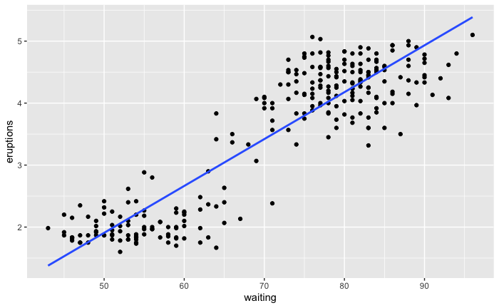

```r
faithful %>%
  ggplot(aes(x = waiting, y = eruptions))+
  geom_point()+
  geom_smooth(method = "lm", se = F)
```

Histograms to visualize and understand the distributions of the wait time and eruption duration:

Interesting Finding: not normal distributions

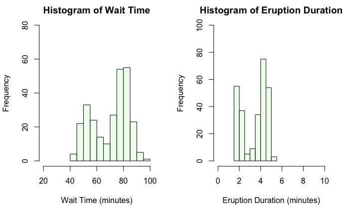

```r
#colors()
par(mfrow=c(1,2)) #divide graph area into two columns

waiting_histogram <- hist(faithful$waiting,
                  col = "honeydew1",
                  # Add title
                  main = "Histogram of Wait Time",
                  # Change x-axis label
                  xlab = "Wait Time (minutes)",
                  # Change y-axis label
                  ylab = "Frequency",
                  # Change x-axis limits
                  xlim = c(20, 100),
                  # Change y-axis limits
                  ylim = c(0, 80),
                  # Change tickmark value orientation
                  # Try values of 0, 1, 2, 3. What happens?
                  las = 0)
eruptions_histogram <- hist(faithful$eruptions,
                  col = "honeydew1",
                  # Add title
                  main = "Histogram of Eruption Duration",
                  # Change x-axis label
                  xlab = "Eruption Duration (minutes)",
                  # Change y-axis label
                  ylab = "Frequency",
                  # Change x-axis limits
                  xlim = c(0, 10),
                  # Change y-axis limits
                  ylim = c(0, 100),
                  # Change tickmark value orientation
                  # Try values of 0, 1, 2, 3. What happens?
                  las = 0)
```

Density Plot: Used to see what the most frequent waiting time and eruption duration was to get a better interpretation of the data.

```r
par(mfrow=c(1,2))

plot(density(faithful$waiting), main = "Density Plot: Waiting", xlab = "Wait Time(mins)",
     ylab = "Frequency")

polygon(density(faithful$waiting), col = "darkgreen")
```

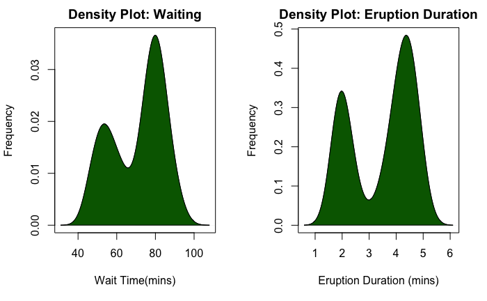

```r
plot(density(faithful$eruptions), main = "Density Plot: Eruption Duration", xlab = "Eruption Duration (mins)",
     ylab = "Frequency")

polygon(density(faithful$eruptions), col = "darkgreen")
```

Boxplot: Used to see how the values in the data are spread out. Not as helpful as the density plot and histograms but an interesting finding in this is that we can see how a 64 minute wait time has the most variety in eruption duration.

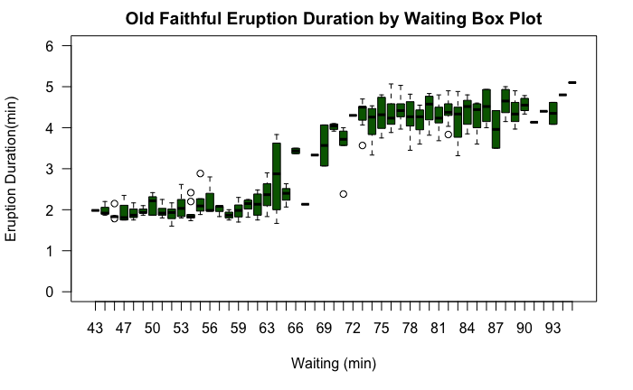

```r
boxplot(faithful$eruptions ~ faithful$waiting,
        # Different colors for each of the five boxes
        col = "darkgreen",
        main = "Old Faithful Eruption Duration by Waiting Box Plot",
        xlab = "Waiting (min)",
        ylab = "Eruption Duration(min)",
        ylim = c(0, 6),
        las = 1)
```

```r
NA
```

FINAL MODEL Least Squares Regression Model: The least squares method is a statistical procedure to find the best fit for a set of data points by minimizing the sum of the offsets or residuals of points from the plotted curve. This model aims to create a straight line that minimizes the sum of the squares of the errors that are generated by the squared residuals.The line of best fit determined from the least squares method has an equation that tells the story of the relationship between the data points. This line of fit helps us to see if there is a relationship or correlation between the two factors being studied and in this model you can see that there is.

Interpretations:

As the wait time increases the eruption time increases.

Interesting Findings: A wait time of around 70 minutes is very uncommon where as around 50 and 80 minutes eruptions are much more common.

```r
eruptions <- faithful$eruptions
waiting <- faithful$waiting
fit <- lm(eruptions ~ waiting)
fit
```

```
Call:
lm(formula = eruptions ~ waiting)

Coefficients:
(Intercept)      waiting
   -1.87402      0.07563
```

```r
attributes(fit)
```

```
$names
 [1] "coefficients"  "residuals"     "effects"
 [4] "rank"          "fitted.values" "assign"
 [7] "qr"            "df.residual"   "xlevels"
[10] "call"          "terms"         "model"

$class
[1] "lm"
```

```r
fit$coefficients[[2]]*2015+fit$coefficients[[1]]
```

```
[1] 150.5163
```

```r
res <- eruptions - (fit$coefficients[[2]]*waiting+fit$coefficients[[1]])
res
```

[output not shown]

[output cut: 53 more lines]

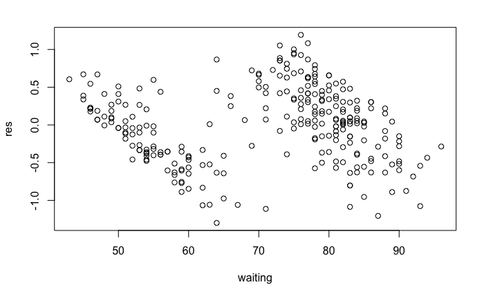

```r
plot(waiting,res)
```

```r
residuals(fit)
```

[output not shown]

[output cut: 55 more lines]

[output not shown]

```r
fit$residuals
```

[output not shown]

[output cut: 55 more lines]

[output not shown]

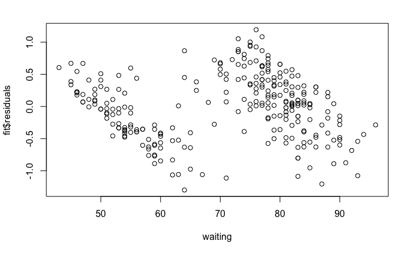

```r
plot(waiting,fit$residuals)
```

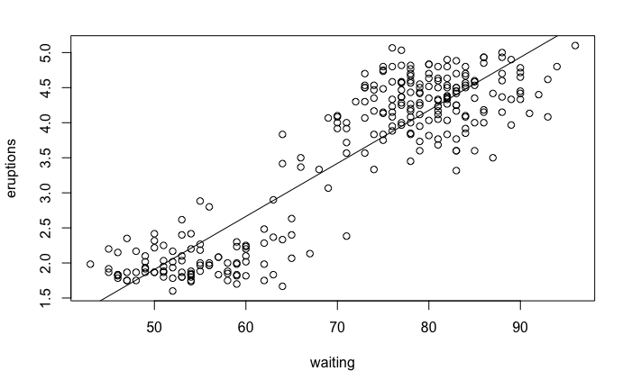

```r
plot(waiting,eruptions)
abline(fit)
```